# Project 2 : Noshowappointments DataSet Analysis

## Research Question 5 :

**Does a certain feature (Scholarship , SMS-received) have an influence on the patient decision?**

**Scholarship Effect :**

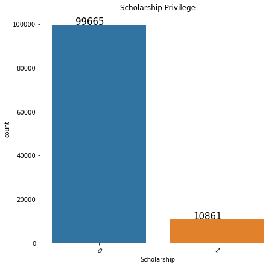

```python
#visualization for Scholarship ratios of people who has it.
Sns_Barcharts(data,'Scholarship',"Scholarship Privilege")
```

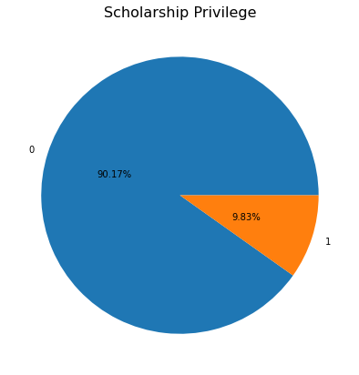

```python
#1 For Have a scholarship 0 for Dont.
Scholarship_patients=data['Scholarship'] == 1
Piecharts(data ,'Scholarship' ,"Scholarship Privilege")
```

We can see from the above charts that their are **9.83%** of the whole dataset population which has a Scholarship Privilege ,so we need a further investigations about their attendance ratios.

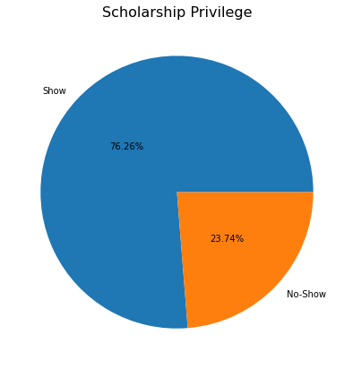

```python
PiechartsGrouby(data ,'Attendance',Scholarship_patients ,"Scholarship Privilege")
```

So according to the above chart we can say that from these **9.83% of people who had a Scholarship 76.26% of them did show up in their appointment day while 23.74% didnt.**

So to make sure that the Scholarship has an effect on the patients we need to look for the other side of the coin & check aswell the poeple who dont have Scholarship Privilege.

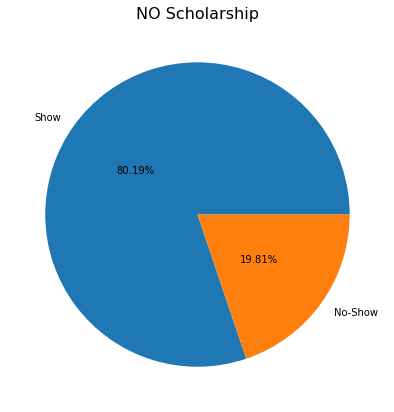

```python
NoScholarship_patients=data['Scholarship'] == 0
PiechartsGrouby(data ,'Attendance',NoScholarship_patients ,"NO Scholarship")
```

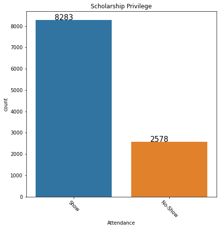

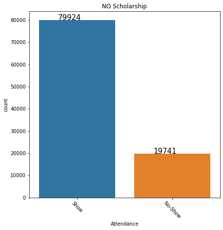

```python
Sns_BarchartsGroupby(data ,'Attendance',Scholarship_patients ,"Scholarship Privilege" )
Sns_BarchartsGroupby(data ,'Attendance',NoScholarship_patients ,"NO Scholarship" )
```

**Sms Effect :**

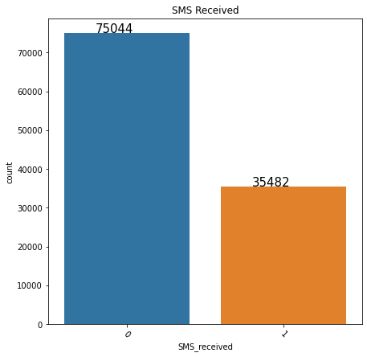

```python
#visualization for Sms ratios.
Sns_Barcharts(data ,'SMS_received' ,'SMS Received' )
```

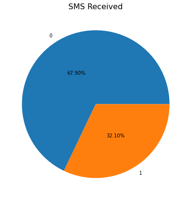

```python
#1 For received 0 for No message sent
Piecharts(data ,'SMS_received',"SMS Received")
```

We can see from the above charts that their are 32.10% of the whole dataset population which has a SMS sent to then,so we need a further investigations about their attendance ratios.

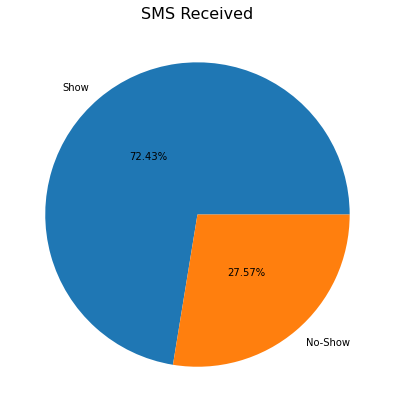

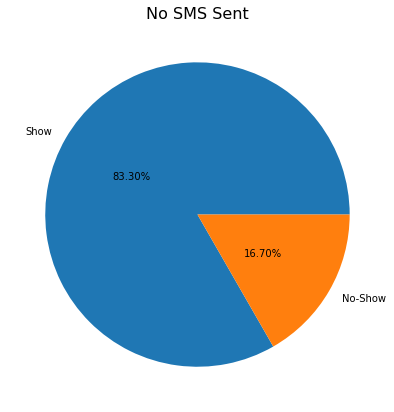

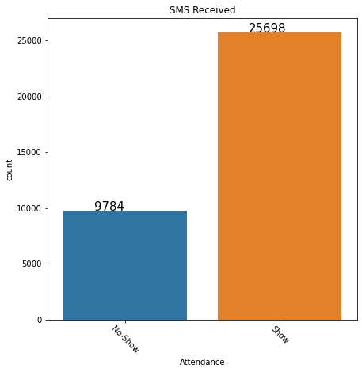

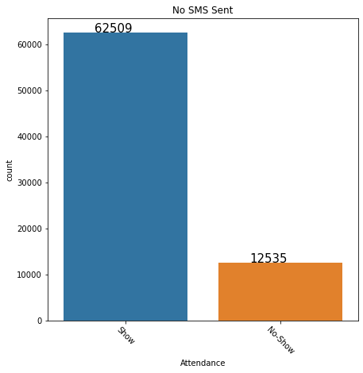

```python
SMS_patients=data['SMS_received'] == True
NO_SMS_patients=data['SMS_received'] == False
PiechartsGrouby(data , 'Attendance' ,SMS_patients ,"SMS Received")
PiechartsGrouby(data , 'Attendance' ,NO_SMS_patients ,"No SMS Sent")
Sns_BarchartsGroupby(data , 'Attendance' ,SMS_patients ,"SMS Received")
Sns_BarchartsGroupby(data , 'Attendance' ,NO_SMS_patients ,"No SMS Sent")
```

## Research Question 6 :

**How is the patient decision does gets affected by their current health status? (any type of illness)**

```python
data
```

|  | Gender | ScheduledDay | AppointmentDay | Age | Neighbourhood | Scholarship | Hypertension | Diabetes | Alcoholism | Handicap | SMS_received | Attendance | Appointment_Day_Of_Week | Age_Group |
| --- | --- | --- | --- | --- | --- | --- | --- | --- | --- | --- | --- | --- | --- | --- |
| 0 | Female | 2016-04-29 | 2016-04-29 | 62 | JARDIM DA PENHA | 0 | 1 | 0 | 0 | 0 | 0 | Show | Friday | 47 -> 69 |
| 1 | Male | 2016-04-29 | 2016-04-29 | 56 | JARDIM DA PENHA | 0 | 0 | 0 | 0 | 0 | 0 | Show | Friday | 47 -> 69 |
| 2 | Female | 2016-04-29 | 2016-04-29 | 62 | MATA DA PRAIA | 0 | 0 | 0 | 0 | 0 | 0 | Show | Friday | 47 -> 69 |
| 3 | Female | 2016-04-29 | 2016-04-29 | 8 | PONTAL DE CAMBURI | 0 | 0 | 0 | 0 | 0 | 0 | Show | Friday | 0 -> 23 |
| 4 | Female | 2016-04-29 | 2016-04-29 | 56 | JARDIM DA PENHA | 0 | 1 | 1 | 0 | 0 | 0 | Show | Friday | 47 -> 69 |
| ... | ... | ... | ... | ... | ... | ... | ... | ... | ... | ... | ... | ... | ... | ... |
| 110522 | Female | 2016-05-03 | 2016-06-07 | 56 | MARIA ORTIZ | 0 | 0 | 0 | 0 | 0 | 1 | Show | Tuesday | 47 -> 69 |
| 110523 | Female | 2016-05-03 | 2016-06-07 | 51 | MARIA ORTIZ | 0 | 0 | 0 | 0 | 0 | 1 | Show | Tuesday | 47 -> 69 |
| 110524 | Female | 2016-04-27 | 2016-06-07 | 21 | MARIA ORTIZ | 0 | 0 | 0 | 0 | 0 | 1 | Show | Tuesday | 0 -> 23 |
| 110525 | Female | 2016-04-27 | 2016-06-07 | 38 | MARIA ORTIZ | 0 | 0 | 0 | 0 | 0 | 1 | Show | Tuesday | 24 -> 46 |
| 110526 | Female | 2016-04-27 | 2016-06-07 | 54 | MARIA ORTIZ | 0 | 0 | 0 | 0 | 0 | 1 | Show | Tuesday | 47 -> 69 |

110526 rows × 14 columns

We need to check the effect these 4 Features :

- **`Hypertension`**
- **`Alcoholism`**
- **`Diabetes`**
- **`Handicap`**

**Hypertension Effect :**

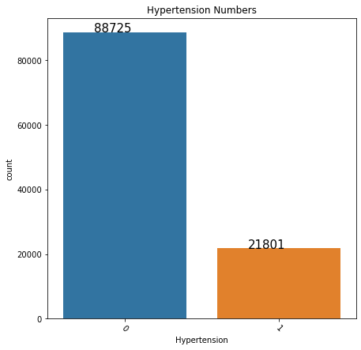

```python
#Visualization for the number of patients who has Hypertension.
Sns_Barcharts(data ,'Hypertension','Hypertension Numbers')
```

[figure not shown]

```python
#1 For have Hypertension issues 0 for dont.
Piecharts(data ,'Hypertension' ,"Hypertension Percentages")
```

We can see from the above charts that their are **19.73%** of the whole dataset population which have a Hypertension,so we need a further investigations about their attendance ratios.

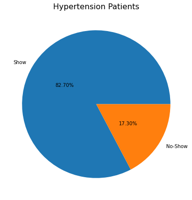

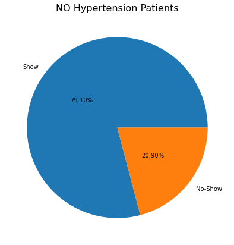

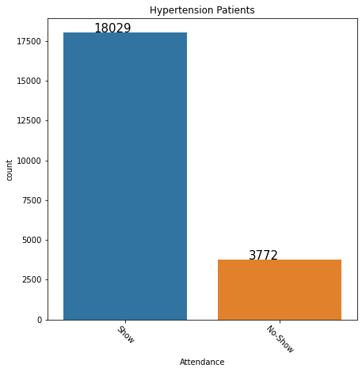

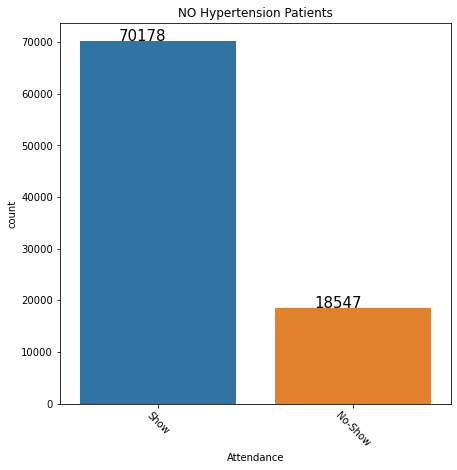

```python
Hypertension_patients=data['Hypertension'] == 1
NO_Hypertension_patients=data['Hypertension'] == 0
PiechartsGrouby(data , 'Attendance' ,Hypertension_patients ,"Hypertension Patients")
PiechartsGrouby(data , 'Attendance' ,NO_Hypertension_patients ,"NO Hypertension Patients")
Sns_BarchartsGroupby(data , 'Attendance' ,Hypertension_patients ,"Hypertension Patients")
Sns_BarchartsGroupby(data , 'Attendance' ,NO_Hypertension_patients ,"NO Hypertension Patients")
```

**So according to the above charts we can say that from these 19.73% of patients who have a Hypertension 82.70% of them did show up in their appointment day while 17.30% didnt.**

**As we can see aswell in next chart it turns out that the ratios are lower for the patients who doesnt have Hypertension with a show up rate of 79.10% ,therefore the Hypertension of a patient does have an effect or a correlation for patients showup rates, which does seems logical since patients who have Hypertension can risk their lives if they miss their appointment day.**

**Alcoholism Effect :**

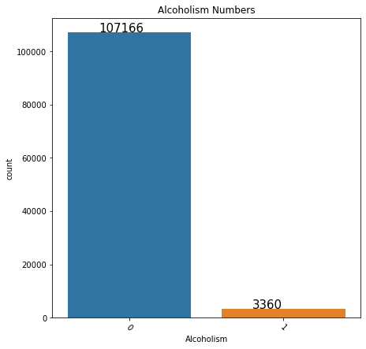

```python
#Visualization for the number of patients who are Alcoholic.
Sns_Barcharts(data ,'Alcoholism','Alcoholism Numbers')
```

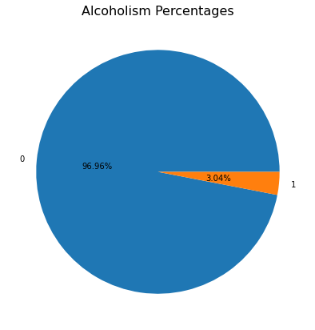

```python
#1 For Alcoholics 0 for Non.
Piecharts(data ,'Alcoholism' ,"Alcoholism Percentages")
```

We can see from the above charts that their are ONLY 3.04% of the whole dataset population which are Alcoholics,so we need a further investigations about their attendance ratios.

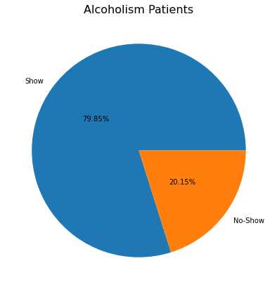

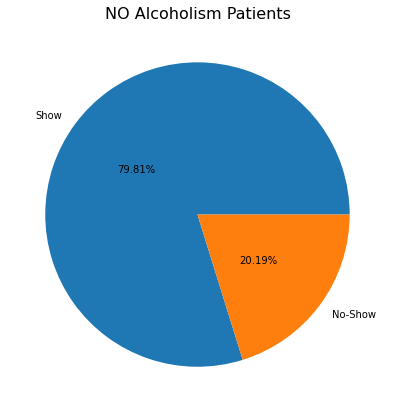

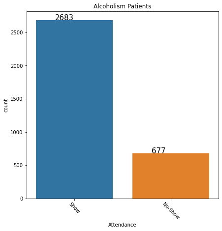

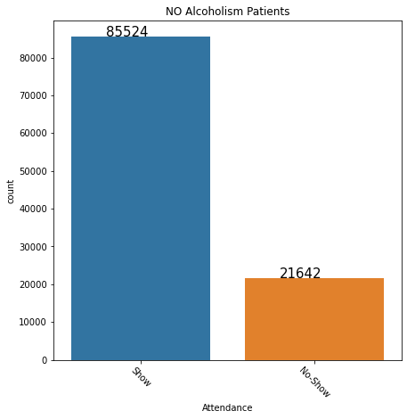

```python
Alcoholism_patients=data['Alcoholism'] == 1
NO_Alcoholism_patients=data['Alcoholism'] == 0
PiechartsGrouby(data , 'Attendance' ,Alcoholism_patients ,"Alcoholism Patients")
PiechartsGrouby(data , 'Attendance' ,NO_Alcoholism_patients ,"NO Alcoholism Patients")
Sns_BarchartsGroupby(data , 'Attendance' ,Alcoholism_patients ,"Alcoholism Patients")
Sns_BarchartsGroupby(data , 'Attendance' ,NO_Alcoholism_patients ,"NO Alcoholism Patients")
```

**So according to the above charts we can say that from these 3.04% of patients who are Alcoholic 79.85% of them did show up in their appointment day while 20.15% didnt.**

Also As we can see in next chart it turns out that the ratios are Very Similar which is 79.81% for the showup rates and 20.19% for No Show rates,**Hence we can say that Alcoholism doesnt really have any effect on the attendance rates of the patients according to this Dataset.**

**Diabetes Effect :**

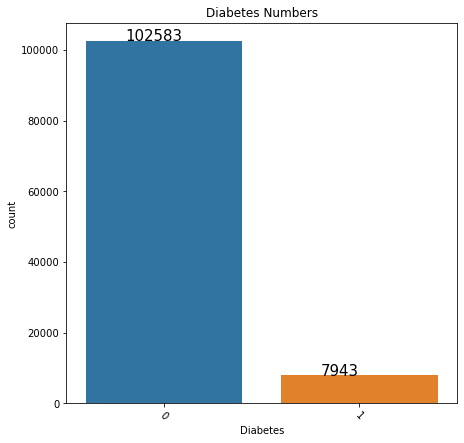

```python
#Visualization for the number of patients who are Diabetic.
Sns_Barcharts(data ,'Diabetes','Diabetes Numbers')
```

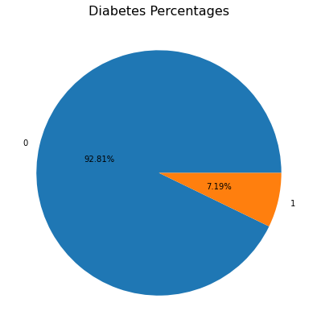

```python
#1 For Diabetic 0 for Non.
Piecharts(data ,'Diabetes' ,"Diabetes Percentages")
```

We can see from the above charts that their are ONLY 7.19% of the whole dataset population which are Diabetic,so we need a further investigations about their attendance ratios.

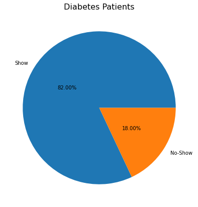

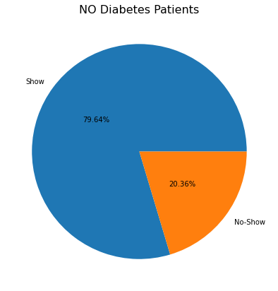

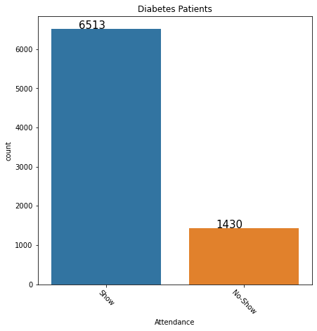

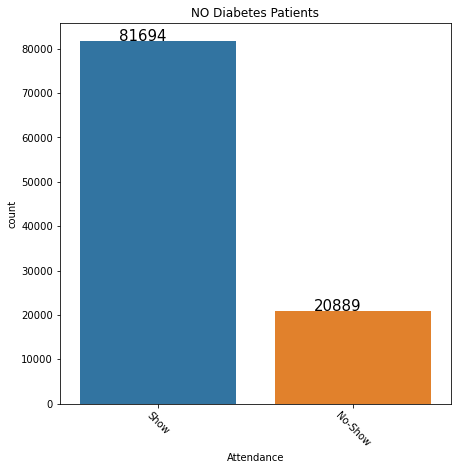

```python
Diabetes_patients=data['Diabetes'] == 1
NO_Diabetes_patients=data['Diabetes'] == 0
PiechartsGrouby(data , 'Attendance' ,Diabetes_patients ,"Diabetes Patients")
PiechartsGrouby(data , 'Attendance' ,NO_Diabetes_patients ,"NO Diabetes Patients")
Sns_BarchartsGroupby(data , 'Attendance' ,Diabetes_patients ,"Diabetes Patients")
Sns_BarchartsGroupby(data , 'Attendance' ,NO_Diabetes_patients ,"NO Diabetes Patients")
```

So according to the above charts we can say that from these 7.19% of patients who are Diabetic 82.00% of them did show up in their appointment day while 18.00% didnt.

Also As we can see in next chart it turns out that the ratios are Lower which is 79.64% for the showup rates and 20.36% for No Show rates ,**Hence we can say that Diabetes does slightly have an effect on the Show up rates of the patients according to this Dataset. with a variance of 2.5%.**

**Handicap Effect :**

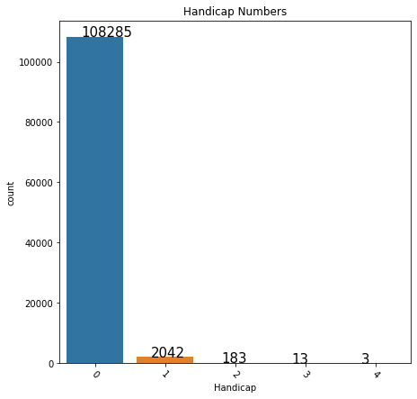

```python
#Visualization for the number of patients who have a Handicap Level. (from level 1 to level 4 ,,,, 0 for non)
Sns_Barcharts(data ,'Handicap','Handicap Numbers')
```

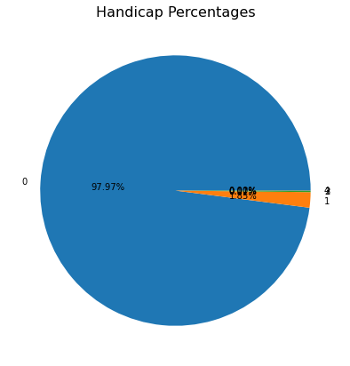

```python
Piecharts(data ,'Handicap' ,"Handicap Percentages")
```

We can see from the above charts that the handicap levels percentages are very small compared to Non handicap patients,so let us check these handicap levels show up rates.

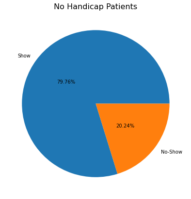

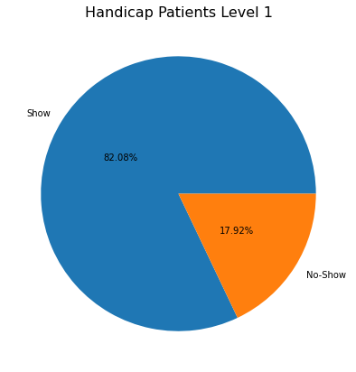

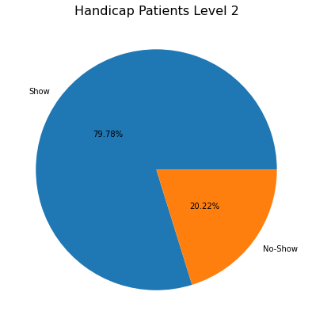

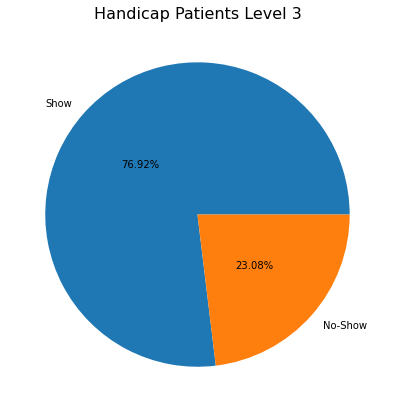

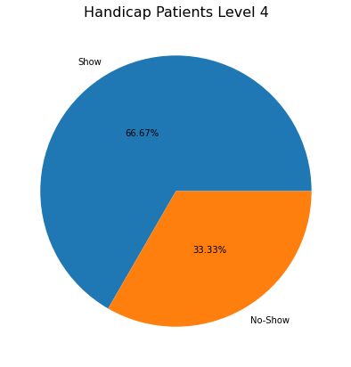

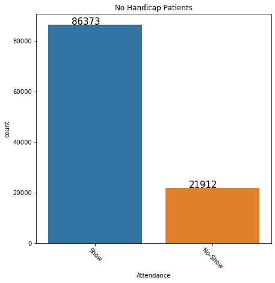

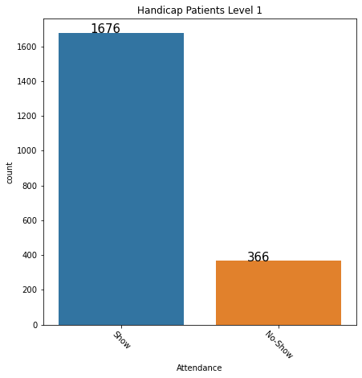

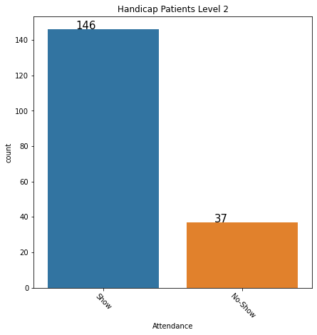

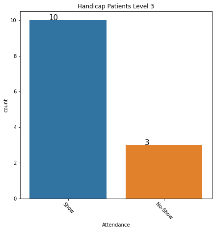

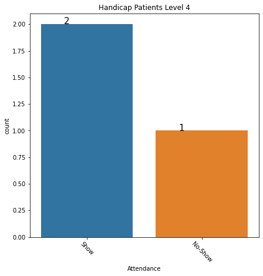

```python
NO_Handicap_patients=data['Handicap'] == 0
Handicap_patients_Level1=data['Handicap'] == 1
Handicap_patients_Level2=data['Handicap'] == 2
Handicap_patients_Level3=data['Handicap'] == 3
Handicap_patients_Level4=data['Handicap'] == 4

PiechartsGrouby(data , 'Attendance' ,NO_Handicap_patients ,"No Handicap Patients")
PiechartsGrouby(data , 'Attendance' ,Handicap_patients_Level1 ,"Handicap Patients Level 1")
PiechartsGrouby(data , 'Attendance' ,Handicap_patients_Level2 ,"Handicap Patients Level 2")
PiechartsGrouby(data , 'Attendance' ,Handicap_patients_Level3 ,"Handicap Patients Level 3")
PiechartsGrouby(data , 'Attendance' ,Handicap_patients_Level4 ,"Handicap Patients Level 4")

Sns_BarchartsGroupby(data , 'Attendance' ,NO_Handicap_patients ,"No Handicap Patients")
Sns_BarchartsGroupby(data , 'Attendance' ,Handicap_patients_Level1 ,"Handicap Patients Level 1")
Sns_BarchartsGroupby(data , 'Attendance' ,Handicap_patients_Level2 ,"Handicap Patients Level 2")
Sns_BarchartsGroupby(data , 'Attendance' ,Handicap_patients_Level3 ,"Handicap Patients Level 3")
Sns_BarchartsGroupby(data , 'Attendance' ,Handicap_patients_Level4 ,"Handicap Patients Level 4")
```

# Conclusions

### Major Findings :

**So in conclusion we have answered all 6 questions we have posed aswell as done the analysis for all the features related to the patients ShowUp rates thus we conclude the following:**

- **`That the Over all ShowUp rate is >> 79.81% and the No show rate is >> 20.19%`**
- **`That the Females Patients numbers are higher than Male Patients with a percentage of 65% to 35%, also that the gender doesnt really affect the attendance levels of the patients.`**
- **`That on the Neighbourhood section we took top 10 ones visited by patients and we observed that JARDIM CAMBURI is the highest visited Neighbourhood with a percentage of appointment of 19.02% and a show up rate of 19.29%,So that can show us the affect of Neighbourhood on the patients attendance levels.`**
- **`That the age group of which has the highest show up rates is Group D with 84.62% From 70 to 92 ,Also the lowest rates are Group A with 77.51% which is from 0 to 23,yet the most populated Group of the entire dataset is Group A with 31.37% of total population,Soby that we can see that Age does play a factor in ShowUp rates of the patients.`**
- **`That the Percentage of patients who have a Scholarship Privilege are 9.83% and the their corresponding Show Up rates are 76.26% , Yet compared to the ratio of patients who doesnt have a Scholarship is somewhat higher with a percentage of 80.20% its clear that the Scholarship Privilege doesnt have any effect to the Patients Show up Rate.`**
- **`That the ratio of the patients who did receive a sms as reminder is 32.10 of the whole population of the dataset,Thus the ShowUp percentage of them is 72.43% meanwhile compared to the patients who didnt receive a sms with a percentage of 83.30%, So it clear from this analysis that the SMS sent as a remainder doesnt have any effect Patients Show Rate.`**
- **`That the total percentage of patients who have a Hypertension Problem are 19.73% & their corresponding Show up rates are 82.70% ,Yet the Show up rate of people who dont is 79.10% ,therefore the Hypertension of a patient does have an effect on the patients showup rates.`**
- **`That the total percentage of patients who have a Diabetes Problem are 7.19% & their corresponding Show up rates are 82.00% ,Yet the Show up rate of people who dont is 79.64% ,therefore the Diabetes does have a slight effect on the patients showup rates.`**
- **`That the total percentage of patients who Are Alcoholic are 3.04% & their corresponding Show up rates are 79.85% ,Yet the Show up rate of people who are not is 79.81% ,Hence we can say that Alcoholism doesnt really have any effect on the attendance rates of the patients.`**

## Limitations

- **We could do a more deep analysis & inspection for the inner-relation & co-relation of different features togther such as Gender with Sms Sent , Alcoholism , Diabetes etc .. that might have any more indications for what does have a high impact on Attendance levels of the patients.**
- **Dataset does lack some important information about location of each patient since its might have a correlation with patients Show up rates.**
- **Further analysis & inspection could be done with the ScheduledDay ,AppointmentDay to get the ammount of time each patient wait till they need to show up.**
- **The visualization of analysis and the data set information is restricted due to project scope.**